# UK Trig Points

Phil Mike Jones

2018-06-18

You need a version of `ggplot2` > 2.2.1 to plot `sf` maps with `geom_sf()` which, as of 2018–06–18, means installing the development version:

```r
if (!requireNamespace("devtools")) {
  install.packages("devtools")
}
devtools::install_github("tidyverse/ggplot2", quiet = TRUE)
```

Load packages for reading in the files, data wrangling, and plotting on a map.

```r
library("tidyverse")
library("sf")
```

Obtain the trig points from the [Ordnance Survey](https://www.ordnancesurvey.co.uk/gps/legacy-control-information/triangulation-stations) and unzip.

```r
dir.create("inst/extdata/", recursive = TRUE, showWarnings = FALSE)

if (!file.exists("inst/extdata/CompleteTrigArchive.zip")) {
  download.file(
    "https://www.ordnancesurvey.co.uk/docs/gps/CompleteTrigArchive.zip",
    destfile = "inst/extdata/CompleteTrigArchive.zip"
  )
}

if (!file.exists("inst/extdata/CompleteTrigArchive.csv")) {
  unzip(
    "inst/extdata/CompleteTrigArchive.zip",
    exdir = "inst/extdata/"
  )
}
```

Load the trig points:

```r
trig = read_csv("inst/extdata/CompleteTrigArchive.csv")
```

The trig points file contains all types of trig points. I’m only interested in those that are pillars (the archetypal [‘Hotine’ pillar](https://en.wikipedia.org/wiki/Triangulation_station#United_Kingdom)).

```r
trig =
  trig %>%
  filter(`TYPE OF MARK` == "PILLAR") %>%
  select(-`TYPE OF MARK`)
```

I’m also not interested in those that are destroyed, so I remove these. The data file we downloaded is no longer being maintained by Ordnance Survey, so some of the pillars left may also be destroyed, but there’s nothing I can do about this for now.

```r
trig =
  trig %>%
  filter(`DESTROYED MARK INDICATOR` == 0L) %>%
  select(-`DESTROYED MARK INDICATOR`)
```

Next convert the table to an `sf` object with geometry for plotting. Here I also set the [CRS](https://en.wikipedia.org/wiki/Spatial_reference_system) to the British National Grid so it plots correctly and so I can transform the points later:

```r
trig =
  trig %>%
  st_as_sf(coords = c("EASTING", "NORTHING"), crs = 27700)
```

Plot a sample of points (otherwise it takes forever) to confirm the points are where they should be:

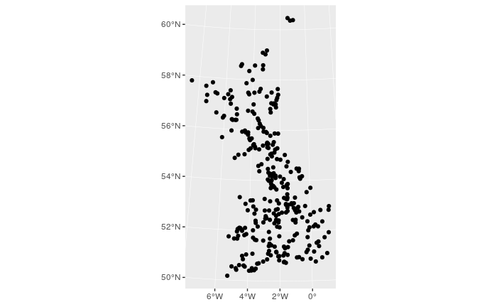

```r
set.seed(42)
trig %>%
  sample_frac(size = 0.05) %>%
  ggplot(.) +
  geom_sf()
```

That roughly looks like the UK. So far, so good.

Now, I want to concentrate on those points around my home (Sheffield). The coordinates of the trig points are given in Easting and Northing, using the [British National Grid](https://en.wikipedia.org/wiki/Ordnance_Survey_National_Grid) (not the high voltage one). The centre of Sheffield is approximately 435100 east and 387100 north. I want to select trig points within about an hour of here, which is about 40km.

```r
sheffield =
  data.frame(
    easting  = 435100,
    northing = 387100,
    stringsAsFactors = FALSE
  ) %>%
  st_as_sf(coords = c("easting", "northing"), crs = 27700)

sheffield =
  trig %>%
  filter(st_within(., st_buffer(sheffield, 40000), sparse = FALSE))
```

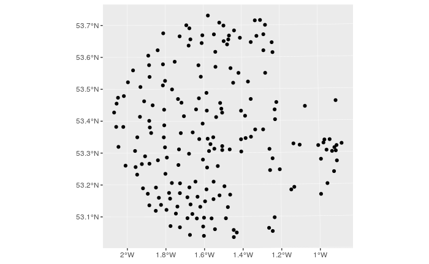

```r
sheffield %>%
  ggplot(.) +
  geom_sf()
```

Before I export these I first need to transform these points to the [Pseudo–Mercator projection](https://epsg.io/3857) so that they work with online mapping tile providers:

```r
sheffield =
  sheffield %>%
  st_transform(crs = 3857)
```

Now to export for use in other GIS software:

```r
dir.create("export/", showWarnings = FALSE)
if (!file.exists("export/sheffield_trigs.shp")) {
  sf::st_write(
    sheffield,
    dsn = "export",
    layer = "sheffield_trigs.shp",
    driver = "ESRI Shapefile"
  )
}
```

```
Field names abbreviated for ESRI Shapefile driver
```

```
Writing layer `sheffield_trigs' to data source `/home/lw1pj/gits/trigr/export' using driver `ESRI Shapefile'
features:       189
fields:         12
geometry type:  Point
```